HOME › R SEMINAR › **MALL OF AMERICA STORE DISTRIBUTION**

# Mall of America Store Distribution.

## Mall of America

While it is well known that many stores have multiple locations within the Mall of America (MOA) it is unclear what proportion of stores are multi-location. To address this fascinating question we downloaded a current directory of the MOA. We processed the data and removed trivial naming differences that don’t truly differentiate stores. For example, Cell Shield East and Cell Shield West had names synonymized to simply Cell Shield).

After this processing we found that the MOA has 517 physical locations made up of only 431 businesses. Five businesses were tied for the most locations (4): Caribou Coffee , Forever 21, lululemon, Sunglass Hut, and Victoria’s Secret.

```r
dat <- read.csv("moa.csv", as.is=T,header=F)
```

# Store types

When walking through the MOA it may feel that many stores are duplicates and this is likely driven by the proportion of locations that are members of businesses with duplicate locations. We found that 29% of all locations are members of duplicates (Figure 1).

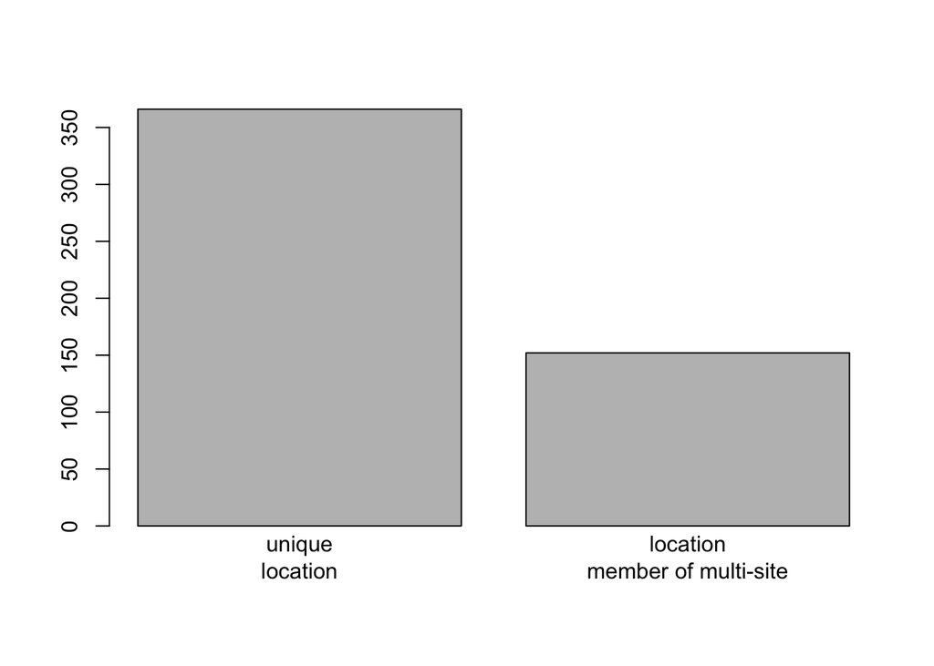

Figure 1 proportion of locations that are members of multi-site businesses.

## Distribution of location counts

Instead we might think about this from the perspective of businesses and ask what percentage of businesses have multiple locations. That value is much smaller - just 15%.

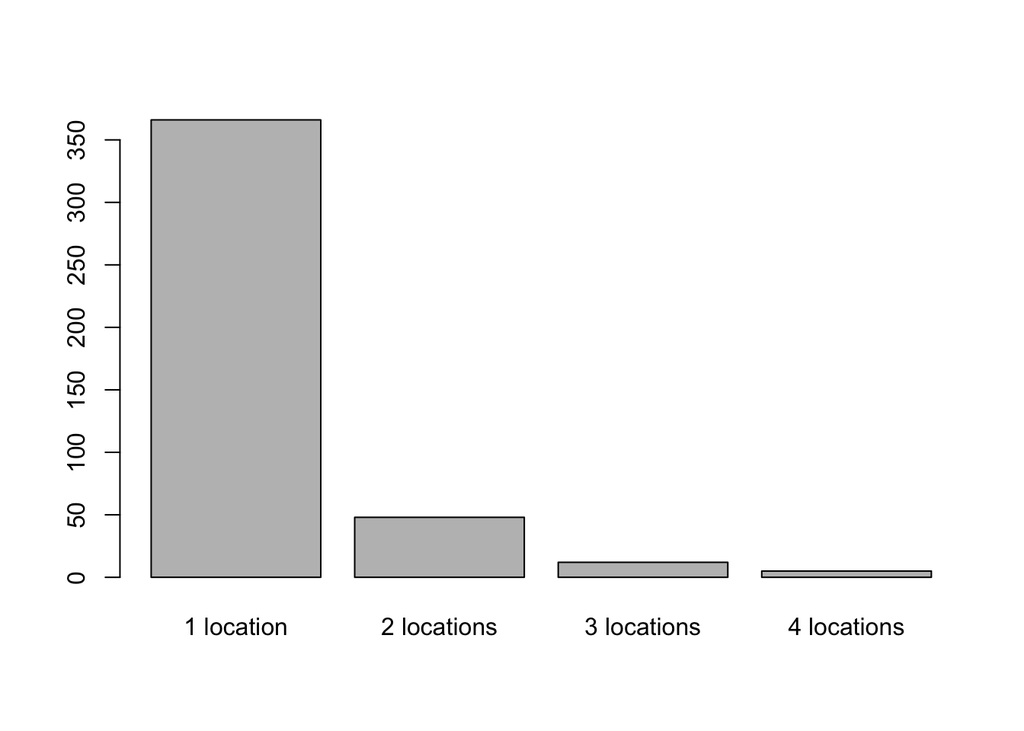

Figure 2 proportion of businesses with varying numbers of locations.